# Cyclistic Case Study

Connor Vaccaro

2022-08-07

# Cyclistic Ride Data Case Study

This is a summary of my analysis for my case study that I performed for Cylistic to analyze how members and non-members use their bikes.

## Install and load packages

First we are including tidyverse for all the functionality it offers. We will also need lubridate for handling date time stamps. We need ggplot2 and scales for making visually appealing plots of our data.

## Gather and load in the datasets

The data was downloaded from Cyclistic’s company data server and covers all of 2021 ride data, separated by month. We are going to read the csv file for each month into its own dataframe

```r
trip_data_2021_01 <- read.csv("202101-divvy-tripdata.csv")
trip_data_2021_02 <- read.csv("202102-divvy-tripdata.csv")
trip_data_2021_03 <- read.csv("202103-divvy-tripdata.csv")
trip_data_2021_04 <- read.csv("202104-divvy-tripdata.csv")
trip_data_2021_05 <- read.csv("202105-divvy-tripdata.csv")
trip_data_2021_06 <- read.csv("202106-divvy-tripdata.csv")
trip_data_2021_07 <- read.csv("202107-divvy-tripdata.csv")
trip_data_2021_08 <- read.csv("202108-divvy-tripdata.csv")
trip_data_2021_09 <- read.csv("202109-divvy-tripdata.csv")
trip_data_2021_10 <- read.csv("202110-divvy-tripdata.csv")
trip_data_2021_11 <- read.csv("202111-divvy-tripdata.csv")
trip_data_2021_12 <- read.csv("202112-divvy-tripdata.csv")
```

Now we want to verify that all of the column names are the same for each dataframe

```r
colnames(trip_data_2021_01) == colnames(trip_data_2021_02)
```

```
##  [1] TRUE TRUE TRUE TRUE TRUE TRUE TRUE TRUE TRUE TRUE TRUE TRUE TRUE
```

```r
colnames(trip_data_2021_02) == colnames(trip_data_2021_03)
```

```
##  [1] TRUE TRUE TRUE TRUE TRUE TRUE TRUE TRUE TRUE TRUE TRUE TRUE TRUE
```

```r
colnames(trip_data_2021_03) == colnames(trip_data_2021_04)
```

```
##  [1] TRUE TRUE TRUE TRUE TRUE TRUE TRUE TRUE TRUE TRUE TRUE TRUE TRUE
```

```r
colnames(trip_data_2021_04) == colnames(trip_data_2021_05)
```

```
##  [1] TRUE TRUE TRUE TRUE TRUE TRUE TRUE TRUE TRUE TRUE TRUE TRUE TRUE
```

```r
colnames(trip_data_2021_05) == colnames(trip_data_2021_06)
```

```
##  [1] TRUE TRUE TRUE TRUE TRUE TRUE TRUE TRUE TRUE TRUE TRUE TRUE TRUE
```

```r
colnames(trip_data_2021_06) == colnames(trip_data_2021_07)
```

```
##  [1] TRUE TRUE TRUE TRUE TRUE TRUE TRUE TRUE TRUE TRUE TRUE TRUE TRUE
```

```r
colnames(trip_data_2021_07) == colnames(trip_data_2021_08)
```

```
##  [1] TRUE TRUE TRUE TRUE TRUE TRUE TRUE TRUE TRUE TRUE TRUE TRUE TRUE
```

```r
colnames(trip_data_2021_08) == colnames(trip_data_2021_09)
```

```
##  [1] TRUE TRUE TRUE TRUE TRUE TRUE TRUE TRUE TRUE TRUE TRUE TRUE TRUE
```

```r
colnames(trip_data_2021_09) == colnames(trip_data_2021_10)
```

```
##  [1] TRUE TRUE TRUE TRUE TRUE TRUE TRUE TRUE TRUE TRUE TRUE TRUE TRUE
```

```r
colnames(trip_data_2021_10) == colnames(trip_data_2021_11)
```

```
##  [1] TRUE TRUE TRUE TRUE TRUE TRUE TRUE TRUE TRUE TRUE TRUE TRUE TRUE
```

```r
colnames(trip_data_2021_11) == colnames(trip_data_2021_12)
```

```
##  [1] TRUE TRUE TRUE TRUE TRUE TRUE TRUE TRUE TRUE TRUE TRUE TRUE TRUE
```

This returns true for all values, so we are clear to join them all into one big dataframe

```r
trips_2021<- bind_rows(
  trip_data_2021_01,
  trip_data_2021_02,
  trip_data_2021_03,
  trip_data_2021_04,
  trip_data_2021_05,
  trip_data_2021_06,
  trip_data_2021_07,
  trip_data_2021_08,
  trip_data_2021_09,
  trip_data_2021_10,
  trip_data_2021_11,
  trip_data_2021_12)
```

Now lets look at those column names

```r
colnames(trips_2021)
```

```
##  [1] "ride_id"            "rideable_type"      "started_at"
##  [4] "ended_at"           "start_station_name" "start_station_id"
##  [7] "end_station_name"   "end_station_id"     "start_lat"
## [10] "start_lng"          "end_lat"            "end_lng"
## [13] "member_casual"
```

We know that we want to look at the ride length of trips, so we’ll add a new column with this data

```r
trips_2021 <- mutate(trips_2021, ride_length = difftime(ended_at, started_at, units = "secs"))
```

# Cleaning the data

The first step in our cleaning process is to remove the data we don’t need, we won’t be using the lat/long coordinates so let’s drop those columns and verify that we have the right columns left

```r
trips_2021 <- subset(trips_2021, select = -c(start_lat:end_lng))

colnames(trips_2021)
```

```
##  [1] "ride_id"            "rideable_type"      "started_at"
##  [4] "ended_at"           "start_station_name" "start_station_id"
##  [7] "end_station_name"   "end_station_id"     "member_casual"
## [10] "ride_length"
```

If we look at the data, we see that there are a lot of zero or negative trip length rides. Without clarification from Cyclistic, we can’t get more information to validate these trips, so we will assume they are errors and drop them.

```r
trips_2021 <- subset(trips_2021, ride_length > 0)
```

# Analyze the data

We are going to add some aggregation columns to the dataframe so we can analyze it by day, month, and hour

```r
trips_2021$day_of_week <- wday(trips_2021$started_at, label=TRUE, abbr=FALSE)
trips_2021$month <- month(trips_2021$started_at, label=TRUE, abbr=FALSE)
trips_2021$hour <- hour(trips_2021$started_at)
```

Next we will summarize the data into separate dataframes for each aggregation. We want to look at counts and average ride length for each aggregation.

```r
#summarize weekly data into one data frame

trips_by_day <- trips_2021 %>%
  group_by(member_casual, day_of_week) %>%
  summarize(mean = mean(ride_length), count = n())
#summarize monthly data into one data frame

trips_by_month <- trips_2021 %>%
  group_by(member_casual, month) %>%
  summarize(mean = mean(ride_length), count = n())
#summarize hourly data into one data frame

trips_by_hour <- trips_2021 %>%
  group_by(member_casual, hour) %>%
  summarize(mean = mean(ride_length), count = n())
```

Next up we’ll plot the data with ggplot2.

First we will remove scientific notation from the plots

```r
options(scipen = 999)
```

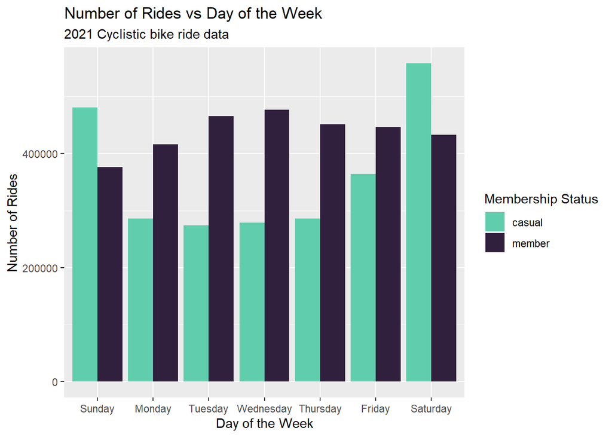

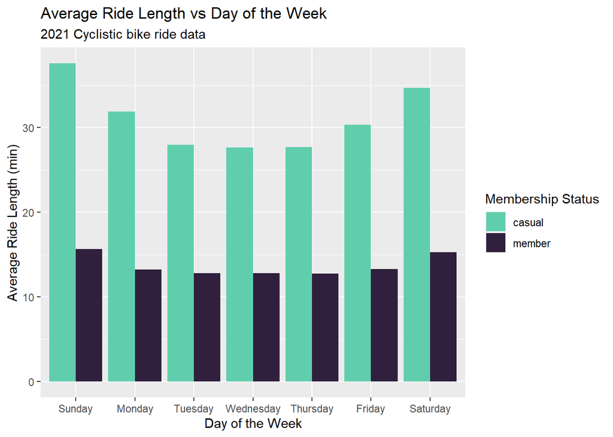

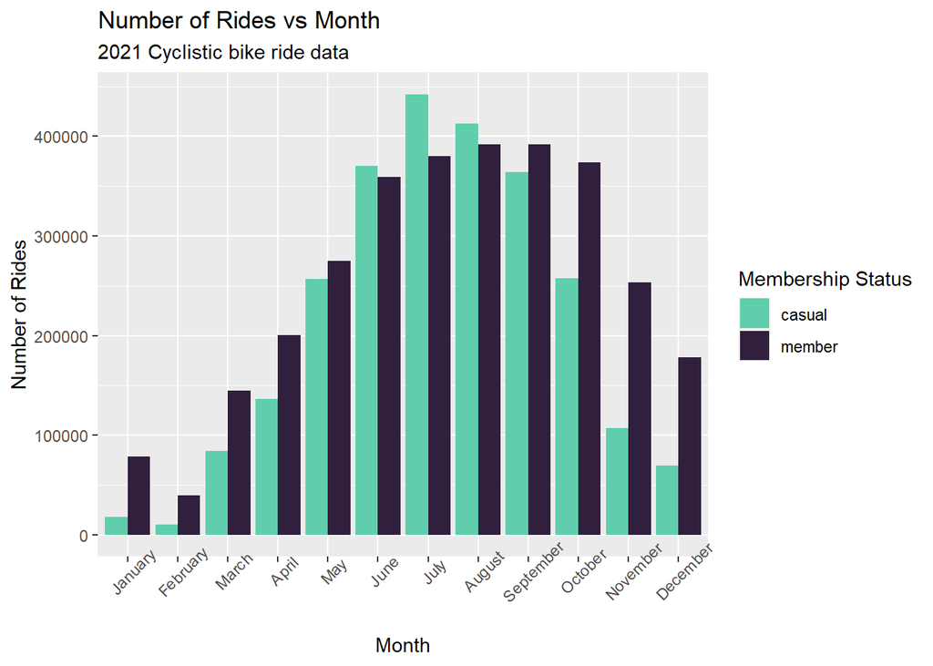

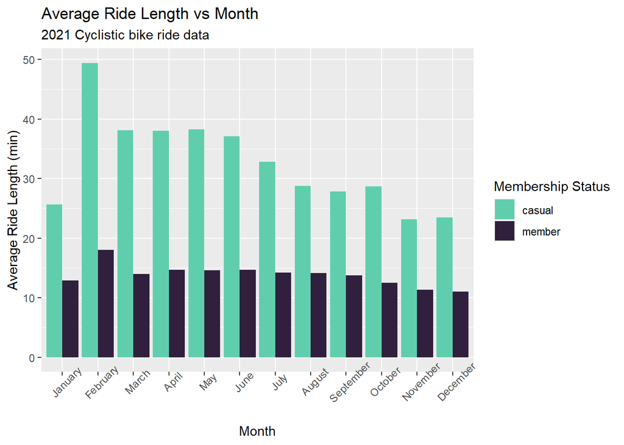

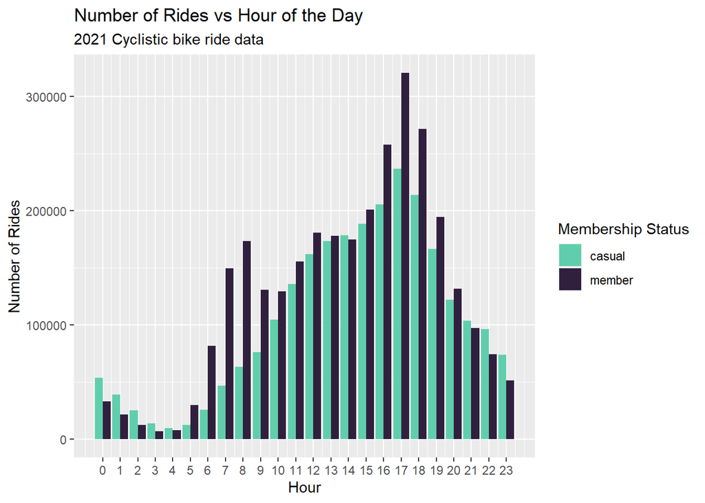

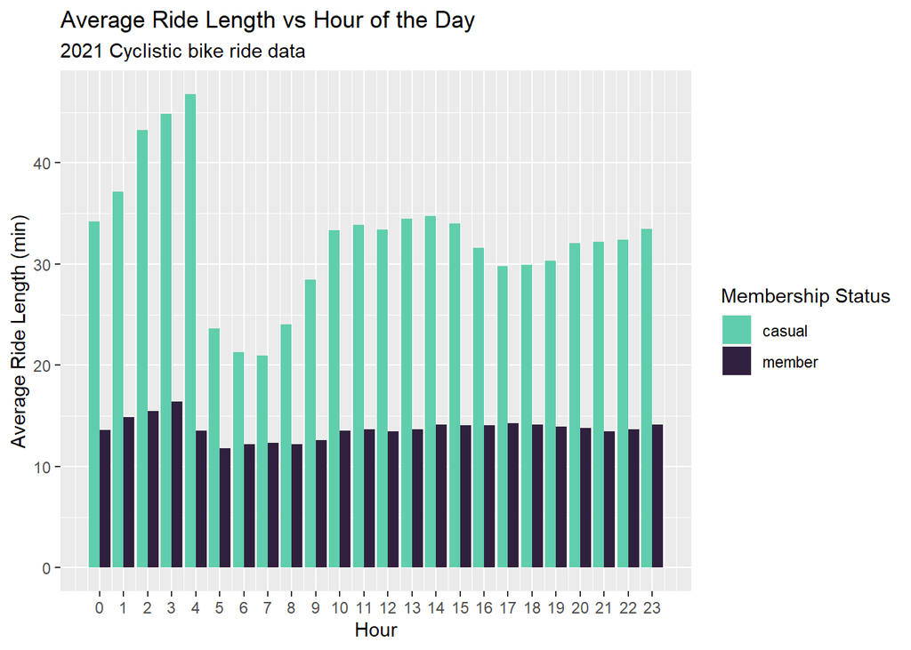